# Mini Project - Multicollinearity

G Radhesyam

1 January 2019

```r
knitr::opts_chunk$set(echo = TRUE)
```

````r
#```{r  include=FALSE,echo=FALSE}
# Set Working Directory
setwd("/home/saisyam/Documents/ACADEMICS_TEACHING/MDH_Workshops/Jan_2019/MultiColliniarity")
getwd()
````

```
## [1] "/home/saisyam/Documents/ACADEMICS_TEACHING/MDH_Workshops/Jan_2019/MultiColliniarity"
```

## Multicollinearity

A basic assumption is multiple linear regression model is that the rank of the matrix of observations on explanatory variables is same as the number of explanatory variables. In other words, such matrix is of full column rank. This in turn implies that all the explanatory variables are independent, i.e., there is no linear relationship among the explanatory variables. It is termed that the explanatory variables are orthogonal.

In many situations in practice, the explanatory variables may not remain independent due to various reasons. The situation where the explanatory variables are highly intercorrelated is referred to as multicollinearity.

### Consequences of multicollinearity

To illustrate the consequences of presence of multicollinearity, consider a model

$y = β_1 x_1 + β_2 x_2 + ε , E ( ε ) = 0, V ( ε ) = σ^{2} I$

where $x_1$ , $x_2$ and y are scaled to length unity.

$Var ( b 1 ) = Var ( b 2 ) = \sigma^{2}/(1-r^{2})$

$Cov ( b 1 , b 2 ) = −r \sigma^{2}/(1-r^{2})$

where r is the correlation coefficient between $x_1$ and $x_2$

If $r → ± 1$, then $Var (b1) =Var (b2) → ∞$

So if variables are perfectly collinear, the variance of OLSEs becomes large. This indicates highly unreliable estimates and this is an inadmissible situation.

| r | 0.99 | 0.9 | 0.1 | 0 |
| --- | --- | --- | --- | --- |
| Var(b1)=Var(b2) | $50\sigma^{2}$ | $5\sigma^{2}$ | $1.01\sigma^{2}$ | $\sigma^{2}$ |

- If r is close to 0, then multicollinearity does not harm and it is termed as **non-harmful** **multicollinearity** .
- If r is close to +1 or -1 then multicollinearity inflates the variance and it rises terribly. This is termed as **harmful** **multicollinearity**.

## Hald Cement Dataset - Data Inspection

### Load HALD CEMENT Dataset

```
##       Y X1 X2 X3 X4
## 1  78.5  7 26  6 60
## 2  74.3  1 29 15 52
## 3 104.3 11 56  8 20
## 4  87.6 11 31  8 47
## 5  95.9  7 52  6 33
## 6 109.2 11 55  9 22
```

```
## 'data.frame':    13 obs. of  5 variables:
##  $ Y : num  78.5 74.3 104.3 87.6 95.9 ...
##  $ X1: int  7 1 11 11 7 11 3 1 2 21 ...
##  $ X2: int  26 29 56 31 52 55 71 31 54 47 ...
##  $ X3: int  6 15 8 8 6 9 17 22 18 4 ...
##  $ X4: int  60 52 20 47 33 22 6 44 22 26 ...
```

## MODEL ANALYSIS and DETAILS

```
##
## Call:
## lm(formula = haldcement$Y ~ ., data = haldcement)
##
## Residuals:
##     Min      1Q  Median      3Q     Max
## -3.1750 -1.6709  0.2508  1.3783  3.9254
##
## Coefficients:
##             Estimate Std. Error t value Pr(>|t|)
## (Intercept)  62.4054    70.0710   0.891   0.3991
## X1            1.5511     0.7448   2.083   0.0708 .
## X2            0.5102     0.7238   0.705   0.5009
## X3            0.1019     0.7547   0.135   0.8959
## X4           -0.1441     0.7091  -0.203   0.8441
## ---
## Signif. codes:  0 '***' 0.001 '**' 0.01 '*' 0.05 '.' 0.1 ' ' 1
##
## Residual standard error: 2.446 on 8 degrees of freedom
## Multiple R-squared:  0.9824, Adjusted R-squared:  0.9736
## F-statistic: 111.5 on 4 and 8 DF,  p-value: 4.756e-07
```

### Scatter plot

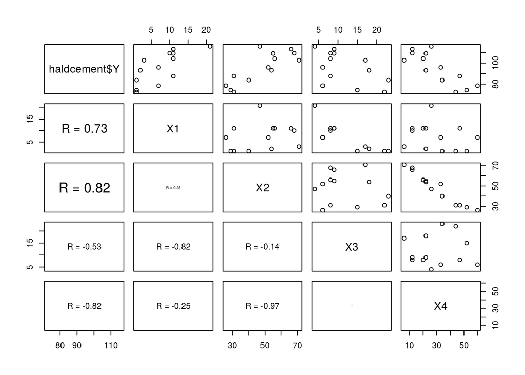

## Outlier Inspection

### Influence points

```r
inflm.HC_LM_1 <-  influence.measures(HC_LM_1)
which(apply(inflm.HC_LM_1$is.inf, 1, any))
```

```
##  1  3  5 10
##  1  3  5 10
```

```r
# which observations 'are' influential
dim(summary(inflm.HC_LM_1)) # only these
```

```
## Potentially influential observations of
##   lm(formula = haldcement$Y ~ ., data = haldcement) :
##
##    dfb.1_  dfb.X1  dfb.X2  dfb.X3  dfb.X4  dffit cov.r   cook.d hat
## 1   0.00    0.00    0.00    0.00    0.00    0.00  4.34_*  0.00   0.55
## 3  -1.10_*  1.03_*  1.08_*  1.08_*  1.10_* -1.24  2.19    0.30   0.58
## 5  -0.02    0.00    0.02    0.00    0.02    0.09  3.00_*  0.00   0.36
## 10 -0.05    0.12    0.04    0.08    0.05    0.30  6.33_*  0.02   0.70
```

```
## [1] 4 9
```

### Influence points analysis

- n= 4 and k= 9
- A Point is an influence point if
  - COOK’s D-statistic(D) > 1
  - DFBETAS > ${2 \over \sqrt{n}} = {2 \over \sqrt{4}} = 1$, i.e DFBETAS > 1
  - DFFITS > $2 * \sqrt{ k \over n} = 2 * \sqrt{9 \over 4} = 3$ , i.e DFFITS > 3
- INFLUENCE POINT
  - Point 3 (as per DFBETAS). None as per DFFITS and cook’s distance D.
- INVESTIGATION
  - Point 3 is within 2 sigma limits of X1,X2,X3 and X4. So retain it

## Multicollinearity inspection

**Variance inflation factors (VIF):**

One or more large VIFs indicate the presence of multicollinearity in the data. **In practice, usually a VIF > 5 or 10 indicates that the associated regression coefficients are poorly estimated because of multicollinearity.**

### Multicollinearity Check

```
##        X1        X2        X3        X4
##  38.49621 254.42317  46.86839 282.51286
```

- OBSERVATION: SEVERE MULTICOLLINEARITY as VIF > 10 FOR ALL VARIABLES

### Correlation Co-efficients - Pearson test

```
##    row column        cor            p
## 1    Y     X1  0.7307175 4.552045e-03
## 2    Y     X2  0.8162526 6.648249e-04
## 3   X1     X2  0.2285795 4.525662e-01
## 4    Y     X3 -0.5346707 5.976232e-02
## 5   X1     X3 -0.8241338 5.308752e-04
## 6   X2     X3 -0.1392424 6.500589e-01
## 7    Y     X4 -0.8213050 5.762318e-04
## 8   X1     X4 -0.2454451 4.189332e-01
## 9   X2     X4 -0.9729550 2.404645e-08
## 10  X3     X4  0.0295370 9.236906e-01
```

- Test of Hypothesis (Pearson)
  - H0: $\rho$ = 0 ; i.e No relationship between the variables.
  - H1 : $\rho$ $\neq$ 0
- OBSERVATION:
  - No Correllation : Accept H0 : X1,X2 (p=0.4); X2,X3 (p=0.6),X1,X4(p=0.4),X3,X4 (p=0.9)
  - Correlation exists : Accept H1 : X1,X3 (< 0.05);X2,X4 (< 0.05)

## Feature Engineering ( Feature Selection)

### Variable Selection - Forward selection

```
##   (Intercept) X1 X2 X3 X4        R2     SSres     AdjR2         Cp
## 1           1  0  0  0  1 0.6745420 883.86692 0.6449549 138.730833
## 2           1  1  0  0  1 0.9724710  74.76211 0.9669653   5.495851
## 3           1  1  1  0  1 0.9823355  47.97273 0.9764473   3.018233
## 4           1  1  1  1  1 0.9823756  47.86364 0.9735634   5.000000
##          BIC
## 1  -9.462884
## 2 -39.007873
## 3 -42.210745
## 4 -39.675391
```

- RECOMMENDATION : X4 +X1 =97%

### Variable Selection - Backward Elimination

```
##   (Intercept) X1 X2 X3 X4        R2     SSres     AdjR2         Cp
## 1           1  0  1  0  0 0.6662683 906.33634 0.6359290 142.486407
## 2           1  1  1  0  0 0.9786784  57.90448 0.9744140   2.678242
## 3           1  1  1  0  1 0.9823355  47.97273 0.9764473   3.018233
## 4           1  1  1  1  1 0.9823756  47.86364 0.9735634   5.000000
##          BIC
## 1  -9.136532
## 2 -42.329587
## 3 -42.210745
## 4 -39.675391
```

- RECOMMENDATION : X2 + X1 = 97%

### Variable Selection - Stepwise Regression

```
##   (Intercept) X1 X2 X3 X4        R2     SSres     AdjR2         Cp
## 1           1  0  0  0  1 0.6745420 883.86692 0.6449549 138.730833
## 2           1  1  1  0  0 0.9786784  57.90448 0.9744140   2.678242
## 3           1  1  1  1  0 0.9822847  48.11061 0.9763796   3.041280
## 4           1  1  1  1  1 0.9823756  47.86364 0.9735634   5.000000
##          BIC
## 1  -9.462884
## 2 -42.329587
## 3 -42.173433
## 4 -39.675391
```

### Variable Selection - PCA

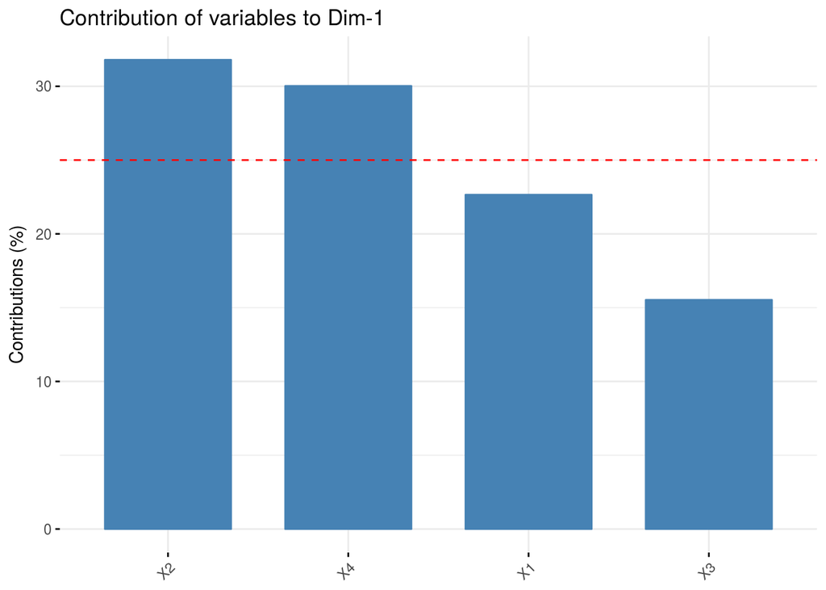

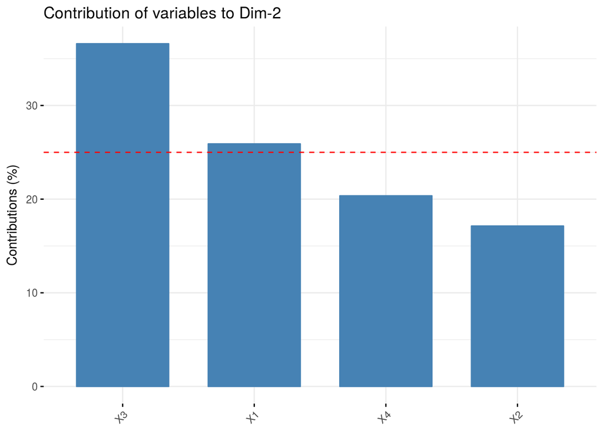

## Model Selection

### Finalizing Variable/Model selection

| VAR | PRESS | VIF | $R^{2}$(adj) | $R^{2}$(pred) |
| --- | --- | --- | --- | --- |
| X1+X2 | 93.8 | 1 | 97% | 96% |
| X2+X4 | 1461.8 | 18 | 61% | 46% |
| X4+X1 | 121.2 | 1 | 96% | 95% |
| X2+X3 | 701.7 | 1 | 81% | 74% |

- RECOMMENDATION :PRESS stat should be small ( so that $R^{2}(pred) is high) and VIF=1.
  - We will go with Model 1 : X1+X2

## Model Adequacy checking

The fitting of linear regression model, estimation of parameters testing of hypothesis properties of the estimator are based on following major assumptions: 1. The relationship between the study variable and explanatory variables is linear, atleast approximately. (L) 2. The error term has zero mean. 3. The error term has constant variance.(E) 4. The errors are uncorrelated. (I) 5. The errors are normally distributed.(N)

LINE * Linearity * Independence * Normality * Equality of Variance

### FINAL Model : X1 + X2

#### Linearity Test

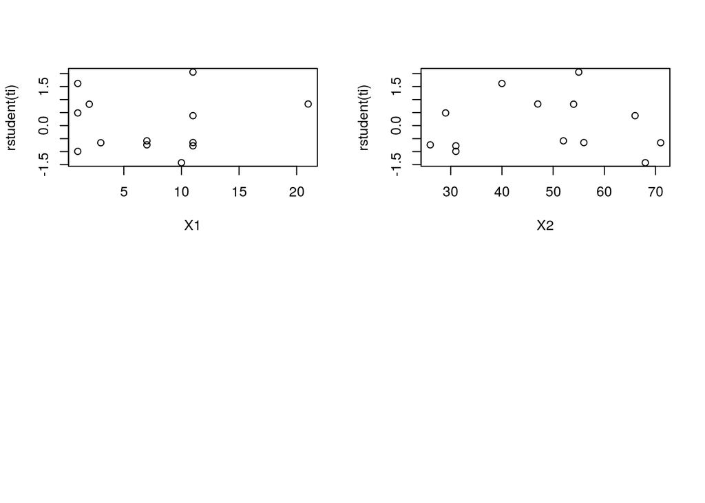

#### Independence Test

```
##  lag Autocorrelation D-W Statistic p-value
##    1     -0.05450402       1.92164   0.948
##  Alternative hypothesis: rho != 0
```

#### Normality Test

```
##
##  Shapiro-Wilk normality test
##
## data:  rstandard(Model_LM_final)
## W = 0.90219, p-value = 0.1433
```

```
##
##  Anderson-Darling normality test
##
## data:  rstandard(Model_LM_final)
## A = 0.61361, p-value = 0.08628
```

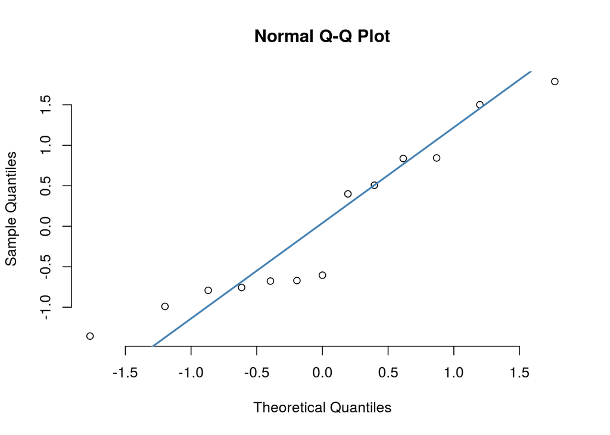

#### Equality of Variance Test

```
##
##  studentized Breusch-Pagan test
##
## data:  Model_LM_final
## BP = 0.16688, df = 2, p-value = 0.9199
```